# Lecture 11

2026-05-05

## Activity 1 (Always Anonymous)

### QR Code or link

This is anonymous & optional, but helpful to Stats 20,

[figure not shown]

or here is a [direct link](https://www.menti.com/bl3ovtgc28d7)

## Introduction to Week 6

At this point in the quarter

- Read in some data
- Manipulate it, change it (if just a little even)
- Summarize it
- Visualize it
- Communicate it

Even if you don’t feel confident today, perhaps in a month you will (just in time for the final)

# Programming in R

## Chapter 4 Braun & Murdoch

- and/or Chapter 1 of Hands On Programming with R by Grolemund
- we need some additional programming skills if you are going to fully utilize your training
- we definitely need programming skills if you are planning on completing the 102 sequence
- we have been using the “functional” aspects of R
- now we pivot to the “procedural” aspects of R - describe to the computer what it must do to complete a task
- this skill helps us to avoid repeating ourselves as programmers
- and frees us to think about other things instead of doing the same things over and over

## Mini Project 1: Two Die/Pair of Dice

- Suppose you were asked to program a game in Stats 102A and it uses two die to determine player movement.
- How do you start to program the behavior of two die?
- Start with one die as the other will look exactly the same.
- We need an R representation of a die.
- Which do you like better?

```r
dieA <- c(1, 2, 3, 4, 5, 6)
dieB <- 1:6
dieC <- seq_len(6)
```

## Check them

```r
all.equal(dieA, dieB)
```

```
[1] TRUE
```

```r
all.equal(dieA, dieC)
```

```
[1] TRUE
```

```r
dieA
```

```
[1] 1 2 3 4 5 6
```

```r
dieB
```

```
[1] 1 2 3 4 5 6
```

```r
dieC
```

```
[1] 1 2 3 4 5 6
```

- All equal, so whichever works best for your style
- `seq_len(n)` creates a sequence the length of n

## Check where we are

1. Create a six outcome representation of a die
2. Generate a random outcome from the 6 possibilities
3. Modify the code so there are two random outcomes, one from each of the die
4. Save the outcome somewhere/somehow so we can use it or study it/etc.

## Generating randomness

`sample()` is the simplest, most basic of sampling functions

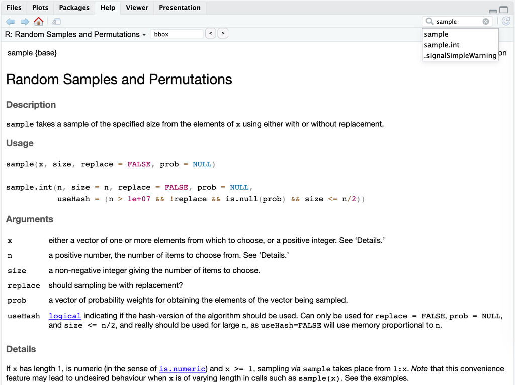

“x” is either a vector of one or more elements from which to choose, or a positive integer.

## Example - obtaining randomness

```r
sample(x = dieA) # a permutation
```

```
[1] 5 3 1 6 2 4
```

```r
sample(x = dieA) # a different permutation
```

```
[1] 6 3 4 2 1 5
```

**But** this isn’t quite what we need, we want our outcomes to look & behave like a pair of real six sided die

1. I want one random side
2. From each of two die

We have the random part now, let’s look at the “one from each of the die” part

## Example - from two die

```r
paste(sample(x = dieA), sample(x = dieA)) # this is so wrong!
```

```
[1] "4 4" "2 1" "1 5" "6 3" "3 2" "5 6"
```

- This is a wrong understanding of how the sample() function works
- I’m permuting the die, then pasting the outcomes together
- Like creating two permuted vectors and then binding them
- Suggestion - we could try reading the documentation more closely on **size** – a non-negative integer giving the number of items to choose from x.
- Or ask AI - but recognizing that the example above is not correctly composed is so important - otherwise we don’t know how/what to ask

```r
paste(sample(x = dieA, size = 1), sample(x = dieA, size = 1)) # better, but can you forsee any problems here?
```

```
[1] "5 6"
```

## Example - size = 2, replace = TRUE

- recall `sampling with replacement` from any intro stats class or text

```r
sample(x = dieA, size = 2, replace = TRUE)
```

```
[1] 3 4
```

- The correctness of this can be understood a number ways, it’s a numeric vector, repeating it generates independent values…

```r
sample(x = dieA, size = 2, replace = TRUE)
```

```
[1] 2 6
```

```r
sample(x = dieA, size = 2, replace = TRUE)
```

```
[1] 1 2
```

```r
sample(x = dieA, size = 2, replace = TRUE)
```

```
[1] 6 2
```

```r
sample(x = dieA, size = 2, replace = TRUE)
```

```
[1] 2 5
```

## Example - size = 2, replace = TRUE (cont’d)

- maybe even sum the two die to better understand dice rolling

```r
sample(x = dieA, size = 2, replace = TRUE) |> sum()
```

```
[1] 8
```

```r
sample(x = dieA, size = 2, replace = TRUE) |> sum()
```

```
[1] 4
```

```r
sample(x = dieA, size = 2, replace = TRUE) |> sum()
```

```
[1] 8
```

```r
sample(x = dieA, size = 2, replace = TRUE) |> sum()
```

```
[1] 4
```

- by now you should be noticing this is boring and repetitive
- we need a function to address this inefficiency

# Function Writing in R

## Automate the Boring using function()

- To create our own functions, use the `function()` function

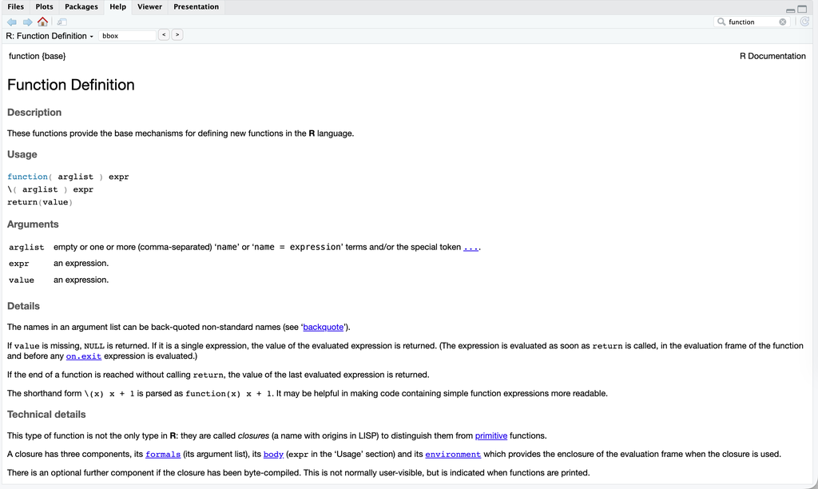

## What is a function in R?

- A function accepts input, processes instructions (code), and generally creates output or does something.
- A function is defined by one or multiple lines of R code inside the body of the function defined by { } (braces).
- Our input (AKA function arguments) can be single or multiple vectors, matrices, lists, etc.
- A function can only output **one** object (but the object could be a vector, matrix, data frame or list).
- Functions help automate tasks and allow for code reuse. (VALUABLE)
- It also allows you to express yourself creatively.

## R function not the same as a math function

| Feature | Math Function | R Function |
| --- | --- | --- |
| Input with Output | Yes | Yes |
| Always same result? | Yes | Not necessarily |
| Side effects/Extras | No | Yes |
| Input types | Mostly numeric | Anything |
| Output types | Usually simple | Can be complex |

- An R function on your laptop can change things external to R (e.g., create a file, create a folder etc.) Math functions are usually self contained.

## You know this by now, but…

- The basic syntax to use (or call) a function is:

```
functionname(argument)
```

- A function has a functionname and parentheses around its arguments.
- Some arguments are required, some are optional, and some have built-in or default values.
- Multiple arguments are separated by commas.

## Writing functions with the function `function()`

- Every function in R can be broken down into 3 parts:
  - a function name
  - the body of code between {} that will be evaluated
  - function arguments that go inside the ()

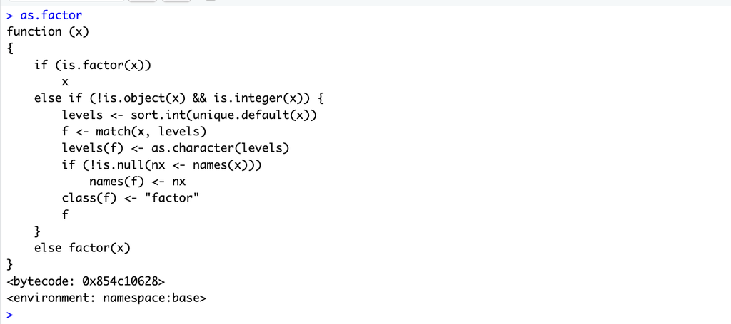

## Bare minimum example

```r
# this works! it's useless but it works!!
my_function <- function(){} # no arguments, no body, just a name
my_function()
```

- Congratulations, this is your first user written function.
- The rest of this lecture is about filling in the empty spaces above with something useful for you

## Example from HoP Ch 1 p. 17

### Consider breaking down the problem into smaller pieces, computational thinking

- Decompose the problem!
- We want a **function** that will imitate the outcome of rolling two six sided die (independent)
- We will name the function “roll”
- We will need to create a six sided die to be rolled (the other is the same)
- We will need to generate two random outcomes (for two die)
- And to make the outcome easier to verify for correctness (always check)
  - we will sum the outcomes

## Translate the steps into something R understands

```r
# indent for easier reading/communicating, R doesn't mind the extra spaces and lines
roll <- function(){
  die <- 1:6
  dice <- sample(die, size =2, replace = TRUE)
  sum(dice) # notice this wasn't assigned to an object
} # notice no response/result from R
```

- Congratulations! You’ve written your first function! Now try it:

```r
# oh oh, we are repeating ourselves again...

roll() # notice what prints out
```

```
[1] 7
```

```r
roll()
```

```
[1] 6
```

```r
roll()
```

```
[1] 3
```

```r
roll()
```

```
[1] 5
```

## Pivot to Braun & Murdoch Chapter 4

- Braun & Murdoch jump right to it and discuss the for() (later…)
- An important goal of this textbook is to introduce you to **stochastic simulation** (very upper division)
- Let’s have a Deterministic System Explanation - A world with no surprises. Water freezes at 0°C. The inputs perfectly guarantee the output. Can use (simple) math to solve problems.
- Constrast it with a Stochastic System Explanation - A world full of surprises. Between 1,000 - 1,200 tornadoes will form in the United States this year, sometimes they destroy property, sometimes they don’t A stochastic model embraces this messiness by injecting a bit of controlled randomness (like rolling dice) into every step of the process.

#### What B & M are trying to tell us: stochastic simulation is using a computer to imitate a process like rolling two dice thousands of times to see what will probably happen when we can’t perfectly predict exactly what will happen.

## The for() in R and loops

- In programming, a loop is called a “loop” because it forces the computer to repeat a specific block of code, jumping back to a previous instruction and running it again.
- This programming structure creates a circular, repetitive path that continues until a specified condition is met, preventing the need to write the same code multiple times. Hence “loop”
- A loop is used to automate anything that might need repeating, like rolling two die, maybe 10,000 times or estimating a model many times on repeated samples to get a stable estimate of variation around its coefficients.
- If you search for the help on `for()` you will encounter “Control Flow”

## Control Flow

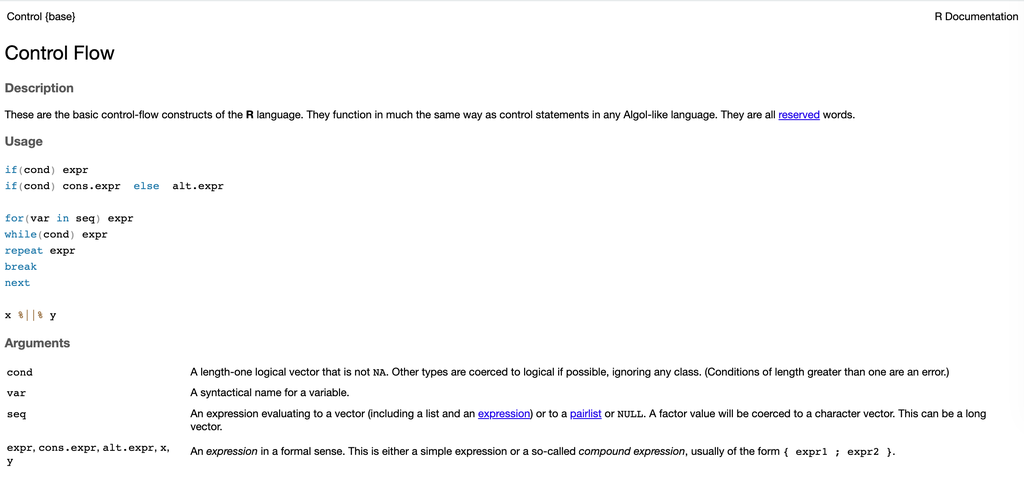

## Control Flow

- Control flow is the order in which a program runs its steps. The documentation states that R is an “ALGOL” like language
- ALGOL (ALGOrithmic Language) was part of the foundation family of imperative programming languages developed in the late 1950s for scientific calculations.
- Imperative programming languages are very structured, top-down, left-right, look at R:

```r
x <- 2
y <- x + 3
print(y)
```

```
[1] 5
```

That’s the DEFAULT control flow: First Step 1 then Step 2 then Step 3 no surprises EXCEPT we can “control” that behavior by using other parts of the R language.

## The for() in action

- The documentation shows us the syntax of the `for()`: **for(var in seq) expr**
- Or from Braun & Murdoch **for (name in vector) {commands}**
- Basically **name** is assigned the elements of a vector and for each value of the vector, whatever is listed in the curly braces will be executed.
- Recall, vectors are the fundamental data structure in R and it is critical to know how to form sequences.
- Braces {} are used for grouping

```r
set.seed(1) # this will give you the exact results in my slide
trials <- 10000
results <- numeric(trials)  # need to store the results - creates zero vector of length 10000
str(results)
```

```
 num [1:10000] 0 0 0 0 0 0 0 0 0 0 ...
```

```r
for (i in seq_len(trials)) {  # generates a sequence as long as trials
    results[i] <- roll()
  }

str(results)
```

```
 num [1:10000] 5 3 8 8 6 6 7 12 3 10 ...
```

```r
table(results)
```

```
results
   2    3    4    5    6    7    8    9   10   11   12
 300  547  822 1080 1412 1655 1418 1082  846  562  276
```

## What is the for() doing?

- It is FORcing R to detour from its normal behavior
- When the code reaches this point:

```
for (i in seq_len(trials)) {
    results[i] <- roll()
  }
```

- It will do what it is being told to do within the {} (the body of the loop) until it is satisfied (reaches the last of trials) then it will move foward again.
- The {} allows multiple lines/commands
- Should indent for clarity
- Notice there is no automatic output, you will need to either save the outcomes or use something like a print()

## Simple example about loop results

```r
for (i in 10:1) {
  i
}
```

- Nothing, but

```r
for (i in 10:1) {
  cat(paste(i, " "))
}
```

```
10  9  8  7  6  5  4  3  2  1
```

- Why `cat()`? It’s “cleaner”

```r
for (i in 10:1) {
  print(paste(i, " "))
}
```

```
[1] "10  "
[1] "9  "
[1] "8  "
[1] "7  "
[1] "6  "
[1] "5  "
[1] "4  "
[1] "3  "
[1] "2  "
[1] "1  "
```

## Visualization

```r
table(results) |> prop.table()
hist(results,  breaks = seq(1.5, 12.5, by = 1), main = "10000 Simulated Rolls of Two Die", freq = FALSE,
xlab = "Sum", ylab = "Density",  sub = "with normal density overlay",
xlim = c(1,13), col = "cyan",  xaxt = "n" ) # xaxt = no default x-axis

axis(1, at = 2:12)  # x axis with ticks at every integer
mu <- mean(results)
sigma <- sd(results)

curve(
  dnorm(x, mean = mu, sd = sigma),
  add = TRUE,
  col = "blue",
  lwd = 2
)
```

## Results

```
results
     2      3      4      5      6      7      8      9     10     11     12
0.0300 0.0547 0.0822 0.1080 0.1412 0.1655 0.1418 0.1082 0.0846 0.0562 0.0276
```

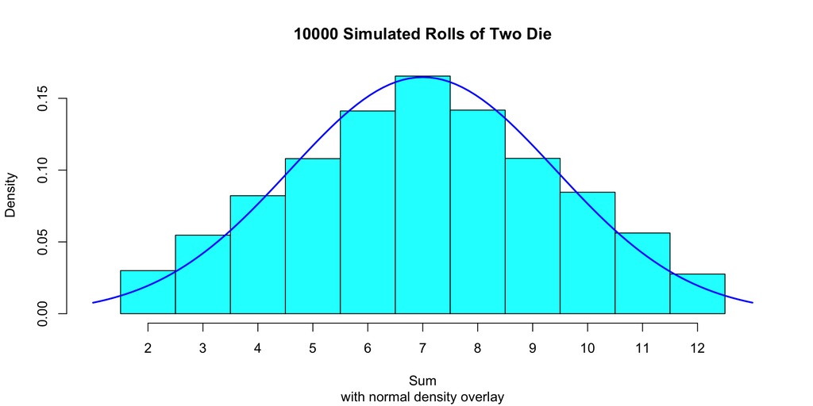

## What if I wanted a million rolls?

```r
set.seed(1) # this will give you the exact results in my slide
trials <- 1000000 # JUST MODIFY IT
results <- numeric(trials)  # need to store the results
str(results)
```

```
 num [1:1000000] 0 0 0 0 0 0 0 0 0 0 ...
```

```r
for (i in seq_len(trials)) {    # seq_len() is preferred over 1:1000000
    results[i] <- roll()
  }

str(results)
```

```
 num [1:1000000] 5 3 8 8 6 6 7 12 3 10 ...
```

```r
table(results)
```

```
results
     2      3      4      5      6      7      8      9     10     11     12
 27769  55280  84058 110715 139122 166795 138824 111121  82831  55809  27676
```

## Visualize

```r
table(results) |> prop.table()
hist(results,  breaks = seq(1.5, 12.5, by = 1), main = paste(trials, "Simulated Rolls of Two Die"),
freq = FALSE, xlab = "Sum", ylab = "Density",  sub = "with normal density overlay",
xlim = c(1,13), col = "cyan",  xaxt = "n" ) # xaxt = no default x-axis

axis(1, at = 2:12)  # x axis with ticks at every integer
mu <- mean(results)
sigma <- sd(results)

curve(
  dnorm(x, mean = mu, sd = sigma),
  add = TRUE,
  col = "blue",
  lwd = 2
)
```

## Result

```
results
       2        3        4        5        6        7        8        9
0.027769 0.055280 0.084058 0.110715 0.139122 0.166795 0.138824 0.111121
      10       11       12
0.082831 0.055809 0.027676
```

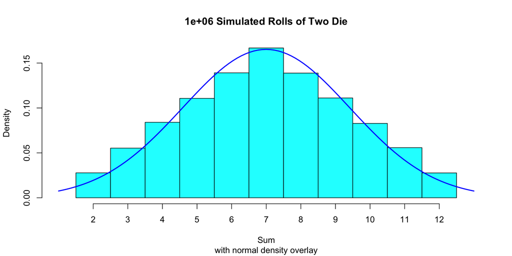

## Very important notes about loops

- Objects created inside the loop will exist in your global environment. They are not hidden.

```r
ls()
```

```
 [1] "dieA"        "dieB"        "dieC"        "i"           "mu"
 [6] "my_function" "results"     "roll"        "sigma"       "trials"
[11] "x"           "y"
```

```r
for (i in seq_len(42)) {
some_result <- i # created object inside the loop, not outside
}
ls()
```

```
 [1] "dieA"        "dieB"        "dieC"        "i"           "mu"
 [6] "my_function" "results"     "roll"        "sigma"       "some_result"
[11] "trials"      "x"           "y"
```

```r
some_result
```

```
[1] 42
```

- Note the value of “some_result”, it is the value of i at the end of loop
- If you haven’t created a vector of some_result outside of the loop, only the last value is saved.

# Break

## Activity #2 Attendance

### Please Greet Your Neighbor(s) and form teams (2 -> Inf)

- Practice greeting others in a safe environment. So it becomes natural.
- Reminder: You cannot receive credit if it’s only you in the photo, please refrain from photoshopping/editing photos
- Reminder: You need to upload the photo for credit.
- Please try to greet & meet a new classmate, take a photograph.
- I’d like your “team” (informal) to work on a few problems together with me

## Example Problem #1 (easy)

- How would you modify our dice rolling example to roll a pair of 20 sided die?

```r
# This won't run without modification
roll <- function(){
  die <-
  dice <-
  sum(dice)
}
# How would you test if it worked?
```

- Those of you who are quick with probability, what is the expected outcome of rolling two 20 sided die?
- If you simulate 100000 rolls using your 20 sided die, is the result consistent with your understanding?

## Example Problem 2 (a little harder)

- American style Mahjong uses 2 die, but as a child I was taught to play Mahjong using 3 die
- How would you modify our dice rolling example to examine the distribution of the outcomes of using 3 6 six-sided die?

## replicate() is vectorized

- `replicate()` is a vectorized function, so instead of using a for loop, I could have

```r
trials <- 1000000
roll3 <- function(){
  die <- 1:6
  dice <- sample(die, size = 3, replace = TRUE)
  sum(dice) # notice this wasn't assigned to an object
}
results_mj3 <- replicate(trials, roll3(), simplify = "vector")

mu <- mean(results_mj3)
sigma <- sd(results_mj3)
max_density <- 1 / (sigma * sqrt(2 * pi)) # we need some math

hist(results_mj3,  breaks = seq(2.5, 19.5, by = 1), main = paste(trials, "Simulated Rolls of Three Die"),
freq = FALSE, xlab = "Sum", ylab = "Density",  sub = "with normal density overlay",
xlim = c(2,19), ylim = c(0, max_density * 1.05), col = "cyan",  xaxt = "n" ) # xaxt = no default x-axis

axis(1, at = 3:18)  # x axis with ticks at every integer

curve(
  dnorm(x, mean = mu, sd = sigma),
  add = TRUE,
  col = "blue",
  lwd = 2
)
```

## Result

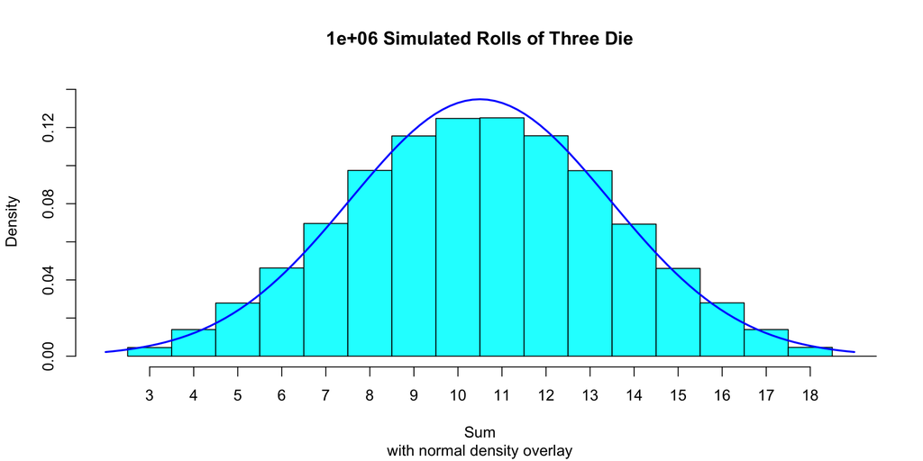

## Why use for()?

```r
set.seed(2)
trials <- 1000000
roll3 <- function(){
  die <- 1:6
  dice <- sample(die, size = 3, replace = TRUE)
  sum(dice) # notice this wasn't assigned to an object
}

results_mj3 <- replicate(trials, roll3(), simplify = "vector")

results <- numeric(trials)
for (i in seq_len(trials)) {  # seq_len for numbers
    results[i] <- roll3()
  }
```

## Timing?

- A well-written `for()` is very fast but might be more difficult to read
- A poorly-written `replicate()` will be both slower and difficult to read

```r
system.time({
  results_replicate <- replicate(trials, roll3(), simplify = "vector")
})
```

```
   user  system elapsed
  3.374   0.014   3.388
```

```r
system.time({
  results_for <- numeric(trials)

  for (i in seq_len(trials)) { # seq_len for numbers
    results_for[i] <- roll3()
  }
})
```

```
   user  system elapsed
  2.569   0.009   2.578
```

The ‘user time’ is the computer processing time spent on your code. The ‘system time’ is the computer processing time spent by Mac or Windows on your computer to help R with what it needed. Elapsed is what you experience.

## for() loop or vectorize code?

- Vectorize when the logic is independent and contained within R
- Loop when the logic is sequential (dependent), reaches outside of R

### 1. State Dependency (Recursive Operations)

Vectorized operations assume that each calculation is independent of the others. A `for` loop is required when **iteration $i$ depends on the result of iteration $i-1$**.

- **Stochastic Simulations:** If you are building a random walk, a Markov chain, or a population model where a future state is calculated using the present state, can’t vectorize (dependent)
- **Complex Accumulation:** If the rules for accumulation change based on the running total (e.g., an account balance that incurs a penalty when it drops below a certain level), a `for` loop provides the necessary control flow.

## for() loop or vectorize code?

### 2. Working with “The Outside World”

Vectorization is designed to work with data inside R’s memory. When your want to interact with the environment outside of R the `for` loop is the correct tool.

- **File Generation:** Iterating through a list to generate and save CSV datasets to a hard drive.
- **Batch Rendering:** Looping through a large dataset to generate and save dozens of visualizations
- **Database Writes:** Adding rows or tables sequentially (slowly) into an external SQL database. Vectorization could cause the database to freeze.